# PCIT-CoS-Waitlist RCT Paper 1: DECA Self Regulation ASD

Nancy Briggs

05 JAN 2021

### DECA Self Regulation Adjusting for ASD

#### Descriptives

| asdcase | group | time | n | mean | sd | median | min | max |
| --- | --- | --- | --- | --- | --- | --- | --- | --- |
| 0 | 1 | 1 | 15 | 41.26667 | 6.912377 | 45.0 | 32 | 53 |
| 0 | 1 | 2 | 16 | 43.18750 | 11.285500 | 41.0 | 28 | 70 |
| 0 | 1 | 3 | 14 | 43.50000 | 7.861787 | 43.5 | 30 | 55 |
| 0 | 2 | 1 | 17 | 36.41176 | 6.452314 | 35.0 | 28 | 53 |
| 0 | 2 | 2 | 9 | 36.66667 | 10.049876 | 35.0 | 28 | 61 |
| 0 | 2 | 3 | 5 | 35.40000 | 7.056912 | 34.0 | 28 | 45 |
| 0 | 3 | 1 | 18 | 43.38889 | 8.430609 | 43.5 | 28 | 58 |
| 0 | 3 | 2 | 22 | 39.63636 | 11.172012 | 37.5 | 28 | 61 |
| 0 | 3 | 3 | 0 | NaN | NA | NA | Inf | -Inf |
| 1 | 1 | 1 | 5 | 34.80000 | 9.959920 | 28.0 | 28 | 50 |
| 1 | 1 | 2 | 4 | 36.50000 | 11.387127 | 32.5 | 28 | 53 |
| 1 | 1 | 3 | 5 | 32.00000 | 3.674235 | 34.0 | 28 | 35 |
| 1 | 2 | 1 | 2 | 39.50000 | 7.778175 | 39.5 | 34 | 45 |
| 1 | 2 | 2 | 2 | 43.00000 | 21.213203 | 43.0 | 28 | 58 |
| 1 | 2 | 3 | 0 | NaN | NA | NA | Inf | -Inf |
| 1 | 3 | 1 | 3 | 41.66667 | 7.637626 | 40.0 | 35 | 50 |
| 1 | 3 | 2 | 4 | 37.50000 | 7.141428 | 36.5 | 30 | 47 |
| 1 | 3 | 3 | 0 | NaN | NA | NA | Inf | -Inf |

[figure not shown]

#### Model & Results

A linear mixed model with random effect for individual and fixed effects of group, time and the interaction was run. ASD status was then entered into the model as a main effect and then the 3-way interaction. Estimated marginal means were obtained, and contrasts specified to test Hypothesis 1 and Hypothesis 2.

```
## fixed-effect model matrix is rank deficient so dropping 1 column / coefficient
```

```
## fixed-effect model matrix is rank deficient so dropping 3 columns / coefficients
```

This is the ANOVA table for the model. p-values are likelihood ratio tests for adding the new term to the model just before. A p-value <0.05 indicates that adding that term results in better model fit. The most important p-value is the interaction p-value.

```
## refitting model(s) with ML (instead of REML)
```

[output not shown]

Model3, the model with Group*Time, adjusted by ASD will be the model I use for Estimated Means.

```r
summary(result3)
```

```
## Linear mixed model fit by REML. t-tests use Satterthwaite's method [
## lmerModLmerTest]
## Formula: outcome ~ asdcase + group * time + (1 | id)
##    Data: dat
##
## REML criterion at convergence: 976.9
##
## Scaled residuals:
##      Min       1Q   Median       3Q      Max
## -1.92333 -0.59951 -0.04659  0.55458  2.95000
##
## Random effects:
##  Groups   Name        Variance Std.Dev.
##  id       (Intercept) 28.32    5.322
##  Residual             55.89    7.476
## Number of obs: 141, groups:  id, 79
##
## Fixed effects:
##              Estimate Std. Error       df t value Pr(>|t|)
## (Intercept)   40.7530     2.0858 127.7037  19.538   <2e-16 ***
## asdcase1      -3.7214     2.3603  70.3902  -1.577    0.119
## group2        -2.9239     2.9115 127.3895  -1.004    0.317
## group3         2.5559     2.8257 128.5887   0.905    0.367
## time2          1.5684     2.4603  75.2330   0.638    0.526
## time3          0.1968     2.5423  83.2747   0.077    0.938
## group2:time2  -0.6263     3.9714  92.2678  -0.158    0.875
## group3:time2  -5.1252     3.3452  74.3247  -1.532    0.130
## group2:time3  -1.2967     4.9234 101.2028  -0.263    0.793
## ---
## Signif. codes:  0 '***' 0.001 '**' 0.01 '*' 0.05 '.' 0.1 ' ' 1
##
## Correlation of Fixed Effects:
##             (Intr) asdcs1 group2 group3 time2  time3  grp2:2 grp3:2
## asdcase1    -0.261
## group2      -0.693  0.098
## group3      -0.704  0.062  0.499
## time2       -0.593  0.023  0.423  0.435
## time3       -0.586 -0.012  0.421  0.434  0.524
## group2:tim2  0.377 -0.050 -0.558 -0.271 -0.620 -0.324
## group3:tim2  0.437 -0.021 -0.311 -0.628 -0.736 -0.385  0.456
## group2:tim3  0.296  0.032 -0.455 -0.223 -0.270 -0.517  0.384  0.198
## fit warnings:
## fixed-effect model matrix is rank deficient so dropping 1 column / coefficient
```

#### Estimated Means & Change

Estimated means for each Treatment and Time (adjusted by ASD status) are presented. In addition, within-group change between time points is presented with 95% CIs.

##### Group mean difference at each timepoint

Effect sizes all calculated by the pooled T1 SD of the outcome. Adjusted p-value from Bonferroni correction.

Group Differences at Each Time Point

| Group Difference | Time | Mean | SE | t | p | adj p | Lower CL | Upper CL | Effect Size | Lower CL | Upper CL |
| --- | --- | --- | --- | --- | --- | --- | --- | --- | --- | --- | --- |
| 1 - 2 | 1 | 2.924 | 2.920 | 1.001 | 0.577 | 0.955 | -4.000 | 9.848 | 0.401 | -0.335 | 0.835 |
| 1 - 3 | 1 | -2.556 | 2.835 | -0.902 | 0.640 | 1.000 | -9.278 | 4.166 | -0.351 | -0.941 | 0.382 |
| 2 - 3 | 1 | -5.480 | 2.881 | -1.902 | 0.142 | 0.178 | -12.313 | 1.353 | -0.752 | -1.224 | 0.014 |
| 1 - 2 | 2 | 3.550 | 3.387 | 1.048 | 0.548 | 0.889 | -4.479 | 11.579 | 0.487 | -0.305 | 1.172 |
| 1 - 3 | 2 | 2.569 | 2.710 | 0.948 | 0.611 | 1.000 | -3.857 | 8.996 | 0.352 | -0.321 | 0.848 |
| 2 - 3 | 2 | -0.981 | 3.251 | -0.302 | 0.951 | 1.000 | -8.689 | 6.728 | -0.135 | -0.863 | 0.585 |
| 1 - 2 | 3 | 4.221 | 4.475 | 0.943 | 0.614 | 1.000 | -6.390 | 14.831 | 0.579 | -0.500 | 1.397 |
| 1 - 3 | 3 | NA | NA | NA | NA | NA | NA | NA | NA | NA | NA |
| 2 - 3 | 3 | NA | NA | NA | NA | NA | NA | NA | NA | NA | NA |

* Effect size scaled by pooled T1 SD  
† ES 95% Bootstrapped Percentile CI limits  
‡ If you want a positive ES (and it is calculated as negative), be sure to switch the signs and positions of the lower and upper CIs.

##### Change within each group

Within-Group Change and Effect Sizes

| Change | Group | Mean | SE | t | p | adj p | Lower CL | Upper CL | Effect Size | Lower CL | Upper CL |
| --- | --- | --- | --- | --- | --- | --- | --- | --- | --- | --- | --- |
| 1 - 2 | 1 | -1.568 | 2.471 | -0.635 | 0.802 | 1.000 | -7.477 | 4.340 | -0.215 | -0.702 | 0.301 |
| 1 - 3 | 1 | -0.197 | 2.559 | -0.077 | 0.997 | 1.000 | -6.303 | 5.910 | -0.027 | -0.604 | 0.503 |
| 2 - 3 | 1 | 1.372 | 2.448 | 0.560 | 0.842 | 1.000 | -4.496 | 7.240 | 0.188 | -0.296 | 0.766 |
| 1 - 2 | 2 | -0.942 | 3.140 | -0.300 | 0.952 | 1.000 | -8.409 | 6.524 | -0.129 | -0.778 | 0.599 |
| 1 - 3 | 2 | 1.100 | 4.260 | 0.258 | 0.964 | 1.000 | -9.025 | 11.225 | 0.151 | -0.728 | 1.121 |
| 2 - 3 | 2 | 2.042 | 4.391 | 0.465 | 0.888 | 1.000 | -8.424 | 12.508 | 0.280 | -0.653 | 1.182 |
| 1 - 2 | 3 | 3.557 | 2.274 | 1.564 | 0.268 | 0.366 | -1.884 | 8.997 | 0.488 | -0.057 | 0.895 |
| 1 - 3 | 3 | NA | NA | NA | NA | NA | NA | NA | NA | NA | NA |
| 2 - 3 | 3 | NA | NA | NA | NA | NA | NA | NA | NA | NA | NA |

* Effect size scaled by pooled T1 SD  
† ES 95% Bootstrapped Percentile CI limits  
‡ If you want a positive ES (and it is calculated as negative), be sure to switch the signs and positions of the lower and upper CIs.

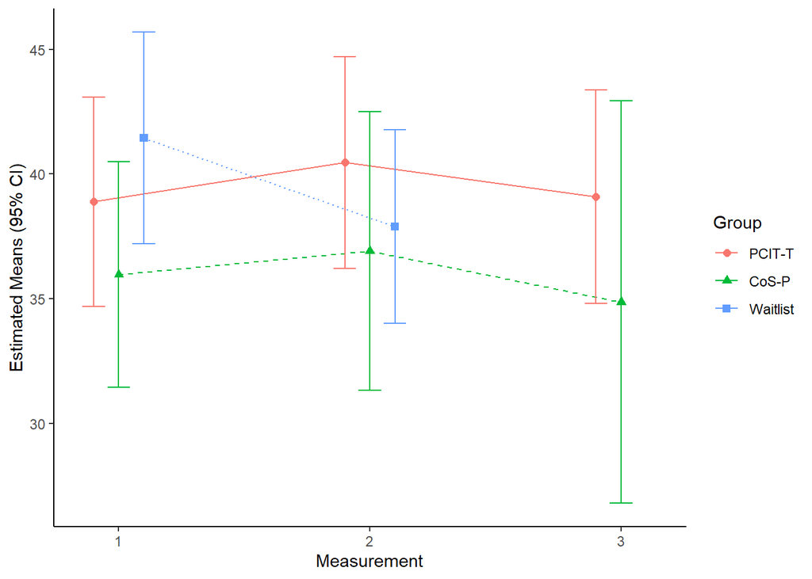

#### Hypothesis 1

We hypothesize that from baseline (‘T1’) to post-treatment/waitlist (‘T2’) there will be a gradient effect, whereby parent-child dyads who receive PCIT-T will show the greatest gains and parent-child dyads who receive no treatment will show the least gains. For the outcome, then, the null hypothesis is:

$H_0: \text {mean change}(\text{PCIT-T}) = \text {mean change}(\text{CoS-P}) = \text {mean change}(\text{Waitlist})$ $H_A: \text {mean change}(\text{PCIT-T}) > \text {mean change}(\text{CoS-P}) > \text {mean change}(\text{Waitlist})$

This is a joint hypothesis test.

First, confirming that the ordering of the means is as hypothesized:

```
## group = 1:
##  contrast estimate   SE    df t.ratio p.value
##  1 - 2      -1.568 2.47  75.4  -0.635  0.8015
##  1 - 3      -0.197 2.56  83.5  -0.077  0.9967
##  2 - 3       1.372 2.45  67.1   0.560  0.8416
##
## group = 2:
##  contrast estimate   SE    df t.ratio p.value
##  1 - 2      -0.942 3.14 103.9  -0.300  0.9516
##  1 - 3       1.100 4.26 107.9   0.258  0.9639
##  2 - 3       2.042 4.39  89.5   0.465  0.8878
##
## group = 3:
##  contrast estimate   SE    df t.ratio p.value
##  1 - 2       3.557 2.27  73.5   1.564  0.2677
##  1 - 3      nonEst   NA    NA      NA      NA
##  2 - 3      nonEst   NA    NA      NA      NA
##
## Results are averaged over the levels of: asdcase
## Degrees-of-freedom method: kenward-roger
## P value adjustment: tukey method for comparing a family of 3 estimates
```

The increase is larger in PCITT than in COSP.

```
##   (Intercept) asdcase1 group2 group3 time2 time3 group2:time2 group3:time2
## 1           0        0      0      0     0     0            1            0
## 2           0        0      0      0     0     0           -1            1
##   group2:time3
## 1            0
## 2            0
```

```
##
##   General Linear Hypotheses
##
## Linear Hypotheses:
##        Estimate
## 1 == 0  -0.6263
## 2 == 0  -4.4989
##
## Global Test:
##       F DF1 DF2 Pr(>F)
## 1 1.359   2 130 0.2605
```

p>0.05, so this joint hypothesis is not supported.

#### Hypothesis 2

There will be a gradient of size of change from T2 to T3 such that the change in the PCIT-T group > the change in the CoS-P group. This isn’t really a gradient; it’s just 1 hypothesis.

First, the change in PCITT and COSP from time 2 to time 3:

```
## group = 1:
##  contrast estimate   SE    df t.ratio p.value
##  1 - 2      -1.568 2.47  75.4  -0.635  0.8015
##  1 - 3      -0.197 2.56  83.5  -0.077  0.9967
##  2 - 3       1.372 2.45  67.1   0.560  0.8416
##
## group = 2:
##  contrast estimate   SE    df t.ratio p.value
##  1 - 2      -0.942 3.14 103.9  -0.300  0.9516
##  1 - 3       1.100 4.26 107.9   0.258  0.9639
##  2 - 3       2.042 4.39  89.5   0.465  0.8878
##
## group = 3:
##  contrast estimate   SE    df t.ratio p.value
##  1 - 2       3.557 2.27  73.5   1.564  0.2677
##  1 - 3      nonEst   NA    NA      NA      NA
##  2 - 3      nonEst   NA    NA      NA      NA
##
## Results are averaged over the levels of: asdcase
## Degrees-of-freedom method: kenward-roger
## P value adjustment: tukey method for comparing a family of 3 estimates
```

```
##
##   Simultaneous Tests for General Linear Hypotheses
##
## Fit: lmer(formula = outcome ~ asdcase + group * time + (1 | id), data = dat)
##
## Linear Hypotheses:
##        Estimate Std. Error z value Pr(>|z|)
## 1 == 0  -0.6704     4.9996  -0.134    0.893
## (Adjusted p values reported -- single-step method)
```

p>0.05, so we do not have enough evidence to suggest that the change from t2 to t3 in PCITT is greater than the change in COSP, adjusting for ASD diagnosis.

#### Residuals

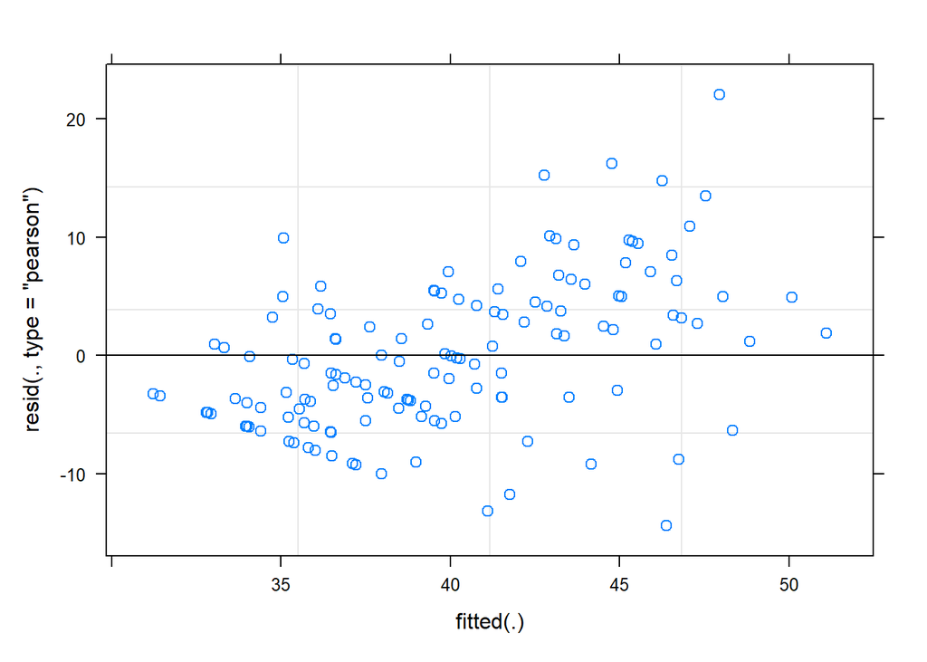

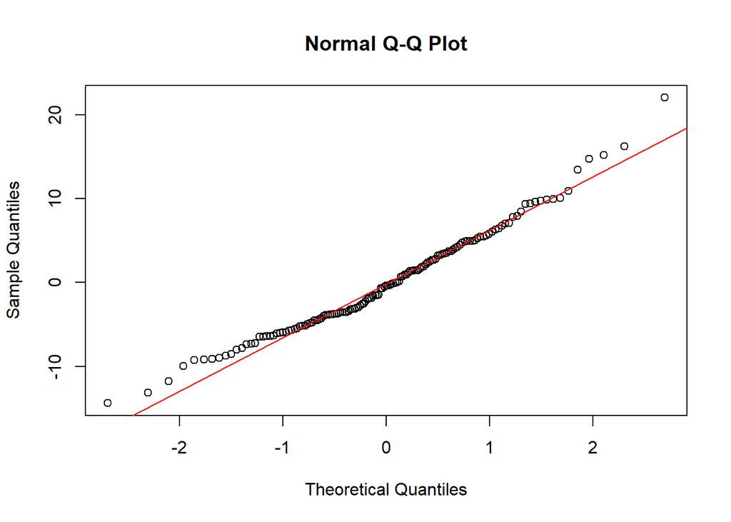

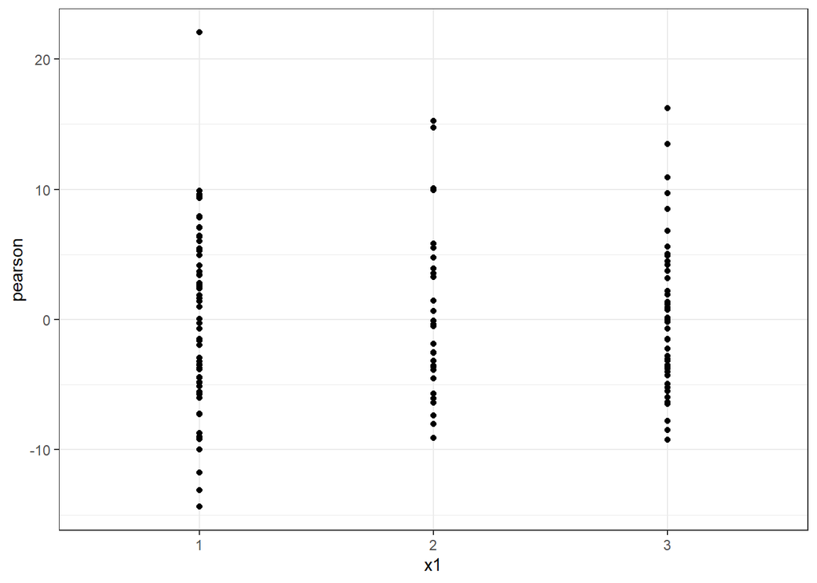

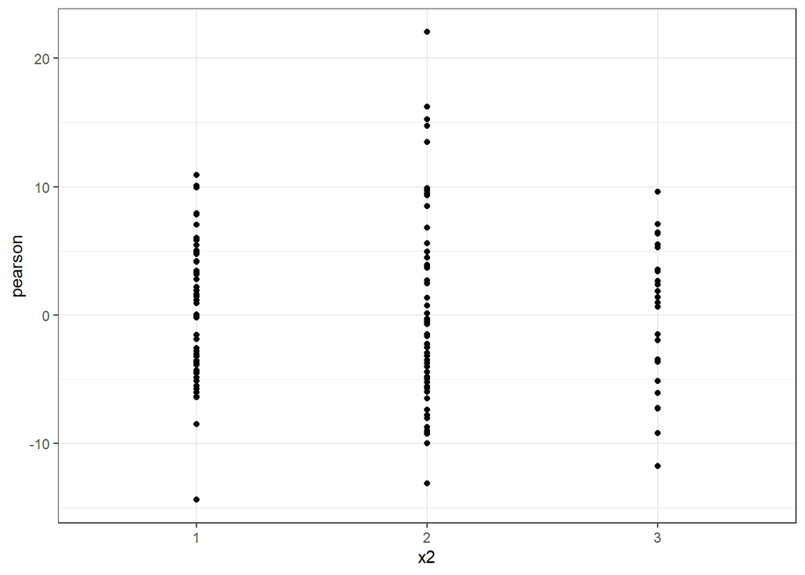

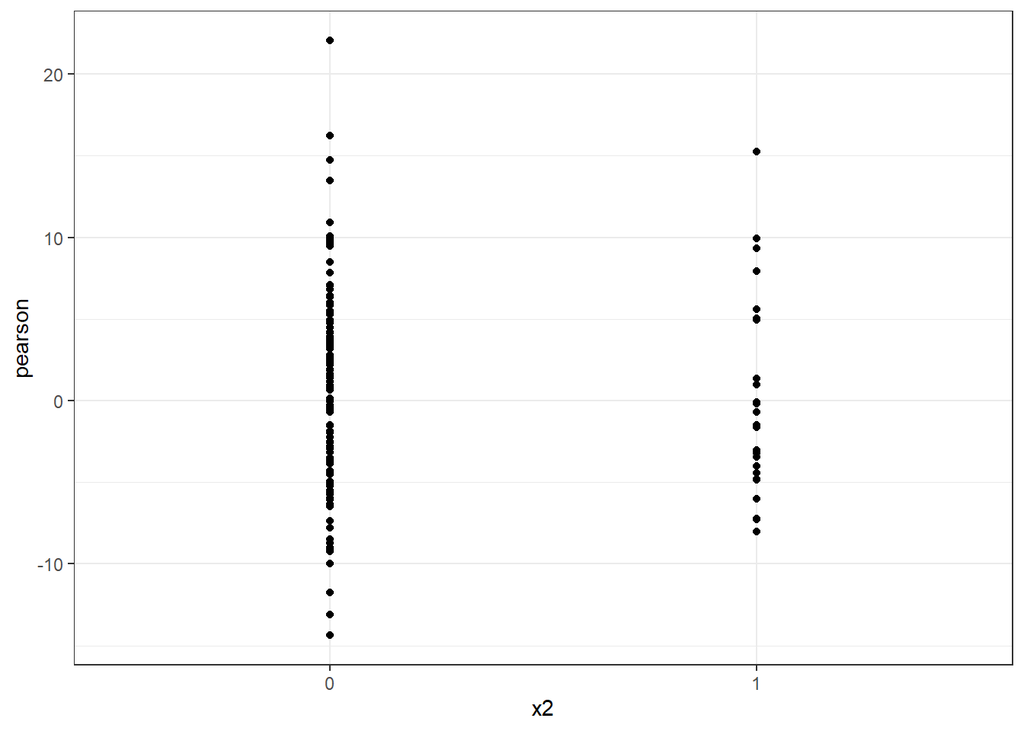

```r
rm(list = ls())
```